# GIS-stitch

Visualizar el cambio climático usando un Sistema de Información Geográfica basado en punto de cruz

Viridiana Lizardo

11 de octubre de 2026

## Cambio climático en mi tiempo de vida

Nací en 1989. Un año antes, se estableció el Palnel intergubernamental sobre el Cambio Climático ([IPCC](https://www.ipcc.ch/)por sus siglas en inglés). Cuando yo cumplí 14 meses de edad, completó su primer reporte: estaban seguros de que las emisiones de gases de invernadero resultantes de las actividades humanas estaban aumentando la temperatura promedio del planeta. Predijeron que bajo el panorama de “Business as usual” (o seguir haciendo lo de siempre), la temperatura aumentaría 0.3º C por década y que ya había aumentado hata 0.6º C durante los últimos 100 años.

Para 2015, se firmó el Acuerdo de París dónde se acordó un esfuerzo conjunto para evitar llegar al aumento de [1.5º C](https://www.ipcc.ch/site/assets/uploads/sites/2/2019/06/SR15_Headline-statements.pdf). El [2 de septiembre de 2026](https://www.unep.org/news-and-stories/press-release/unep-world-set-cross-15degc-global-warming-can-still-limit-adapt-and), oficialmente se anunció que hemos pasado ese umbral. Los riesgos e impactos por encima de los 1,5 °C se intensifican (súbita o gradualmente) con cada fracción adicionalde grado. En sus efectos está:

- La Intensificación de los fenómenos meteorológicos extremos.
- Los glaciares podrían perder más de una cuarta parte de sumasa para 2100, elevando el nivel del mar 12,5 cm.
- Graves daños para la salud humana, la seguridad alimentaria, los suministros deagua, la naturaleza, las ciudades, las infraestructuras y las economías.
- La producción mundial de alimentos podría disminuir hasta un 14 % para 2050 en ausencia de medidas eficaces de adaptación.
- Cambios irreversibles en las capas de hielo, en la circulación de vuelco meridional del Atlántico y en el bosque lluvioso amazónico.

Según la [UNAM](https://cambioclimatico.unam.mx/mexico-climatico/), ya tenemos un aumento de 1.9º C en México y está aumentando 0.5º C por década. En Zacatecas, dónde nací, el diciembre y mayo son 2.7º C más cálidos. Pero en Sonora, el invierno es hasta 4º C más cálido.

Como parte de la normatividad establecida por la Organización Meteorológica Mundial, el Servicio Meteorológico Nacional realiza el cálculo de las normales climatológicas, cada 10 años para un periodo consecutivo de 30 años.

**En mi tiempo de vida**, se han calculado al menos tres climatologías, y ha pasado un periodo completo.

**En mi tiempo de vida** los tomadores de deciciones firmaron una promesa y la rompieron.

**En mi tiempo de vida** la humanidad está destruyendo su hogar, el que compartimos con tantos otros seres.

### ¿Hay esperanza?

Se propone una estrategia de llegar al punto máximo y descenso para lograr que las temperaturas vuelvan a situarse en o por debajo de los 1,5 °C de sobrepaso antes de finales de siglo.

En este año se están calculando los nuevos escenarios climáticos a futuro, se están haciendo planes de adaptación y mitigación a nivel nacional y global. De acuerdo con el [informe](https://www.unep.org/resources/limiting-overshoot-navigating-exceedance), la clave está en una acción rápida, colectiva y global con firme voluntad política y multilateralismo, que incluyan políticas eficaces, gobernanza inclusiva y el financiamiento adecuado.

Este año me ha tocado trabajar en describir cómo ha cambiado México con datos. Es devastador per, al menos, me ha tocado vida para hacer algo al respecto. Este año voy a hacer un registro del cambio climático que ha habido en mi vida, esperando que sea un punto de inflexión.

## Métodos

Que es GIS-stitch

Un sistema de información geográfica (SIG o GIS, por sus siglas en inglés) es un conjunto de herramientas para guardar, analizar y representar datos que tienen un lugar en la superficie de la Tierra. Un formáto ampliamente utilizado en éstos es formato ráster: una cuadrícula en la que cada celda guarda un valor, como la temperatura o la lluvia de un territorio. Este formato permite el análisis masivo de datos geográficos: para este mapa, la computadora procesó unos millones de valores mensuales y resumió el cambio en 706 celdas que conforman un mapa de México a una resolución de 0.5º.

Los datos ráster consisten en coordenadas X (longitud), Y, (Latitud) y Z (dato). Este mismo formato lo tiene un patrón de punto de cruz: posición y color. Al dejar una versión en físico de este mapa, se hace un archivo inmutable e independiente de formatos, servidores y electricidad.

Bordar y programar se asemajan: ambas cosas siguen instrucciones paso a paso, cuentan, repiten y dependen de una clave que traduce símbolos en acciones. En el bordado existe el término [“muestrario” o “dechado”](https://egausa.org/mexican-dechados-mayela-flores-lynne-anderson/), una pieza que demuestra la capacidad de una bordadora que combina distintas puntadas. Este es mi muestrario de habilidades de programación, análisis de datos, bordado y creación artística.

### Análisis de datos

Se usan datos mensuales desde 1958 hasta 2025 a una resolución de 4 km. Estos sob obtenidos de **TerraClimate** (Abatzoglou et al., 2018), a través del paquete de R `climateR`. Se descargaron los datos de:

- **Temperatura media anual** (°C): promedio de `(tmax + tmin) / 2` en los 12 meses.
- **Precipitación anual** (mm): suma de los 12 meses.

Cada año se enmascara al territorio de México y se promedia en celdas de 0.5°. Una celda se conserva si al menos la mitad de su superficie tiene datos dentro del país.

La descarga y la agregación están en `analysis/03_series_anuales.R`. Este es su núcleo:

```r
anio_tc <- function(anio) {
  m <- getTerraClim(AOI = mex, varname = c("tmax", "tmin", "ppt"),
                    startDate = paste0(anio, "-01-01"),
                    endDate = paste0(anio, "-12-01"))

  r <- c(mean((m$tmax + m$tmin) / 2),   # °C, media de los 12 meses
         sum(m$ppt))                     # mm, total del año
  names(r) <- c("temp", "prec")
  r
}
```

El resultado es una tabla con una fila por celda y año:

```r
setwd("C:/Users/USER/Documents/GitHub/GIS_stitch/")
options(clima.solo_funciones = TRUE)     # cargar funciones sin correr el ejemplo

source("analysis/02_patron_bordado.R")    # también carga analysis/clases.R

series <- read.csv("data/series_anuales_05deg.csv")
head(series)
```

| anio | lon | lat | temp | prec |
| --- | --- | --- | --- | --- |
| 1958 | -116.75 | 32.25 | 18.06 | 342.8 |
| 1958 | -116.25 | 32.25 | 15.09 | 344.5 |
| 1958 | -115.75 | 32.25 | 18.28 | 213.5 |
| 1958 | -115.25 | 32.25 | 21.58 | 57.1 |
| 1958 | -114.75 | 32.25 | 23.04 | 61.4 |
| 1958 | -114.25 | 32.25 | 22.99 | 96.7 |

```r
c(celdas = nrow(unique(series[c("lon", "lat")])),
  desde  = min(series$anio),
  hasta  = max(series$anio))
```

```
## celdas  desde  hasta
##    706   1958   2025
```

### Cambio climático en México

Antes del mapa, la serie nacional. Promedio las celdas ponderando por su área (las celdas del norte son un poco más pequeñas que las del sur).

```r
series$peso <- cos(series$lat * pi / 180)
nacional <- do.call(rbind, lapply(split(series, series$anio), function(s)
  data.frame(anio = s$anio[1],
             temp = weighted.mean(s$temp, s$peso),
             prec = weighted.mean(s$prec, s$peso))))

v <- ventanas(series, anio = 1989)        # 1989-1998 frente a 2016-2025
v[c("inicial", "final")]
```

```
## $inicial
## [1] "1989-1998"
##
## $final
## [1] "2016-2025"
```

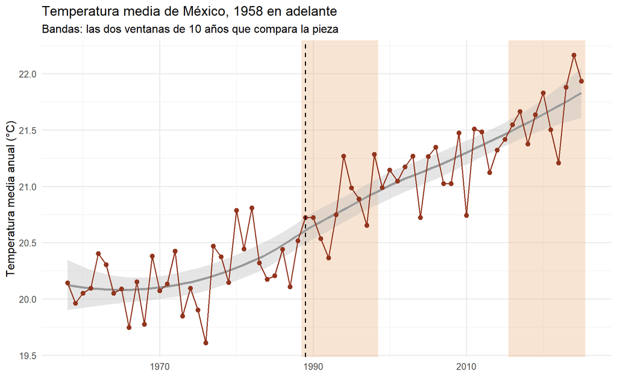

```r
rango <- function(et) as.numeric(strsplit(et, "-")[[1]])
sombra <- data.frame(xmin = c(rango(v$inicial)[1], rango(v$final)[1]) - 0.5,
                     xmax = c(rango(v$inicial)[2], rango(v$final)[2]) + 0.5)

ggplot(nacional, aes(anio, temp)) +
  geom_rect(data = sombra, aes(xmin = xmin, xmax = xmax, ymin = -Inf, ymax = Inf),
            inherit.aes = FALSE, fill = "#ecb27d", alpha = 0.35) +
  geom_smooth(colour = "grey60", fill = 'grey75')+
  geom_line(colour = "#92351e") +
  geom_point(colour = "#92351e", size = 2) +
  geom_vline(xintercept = 1989, linetype = 'dashed')+

  labs(x = NULL, y = "Temperatura media anual (°C)",
       title = "Temperatura media de México, 1958 en adelante",
       subtitle = "Bandas: las dos ventanas de 10 años que compara la pieza") +
  theme_minimal(base_size = 12)
```

### Calculando los valores por celda

Para cada celda:

- **Temperatura:** promedio de 2016–2025 menos promedio de 1989–1998, en °C.
- **Precipitación:** el mismo cambio, pero relativo: `(final − inicial) / inicial × 100`, en %.

Promediar 10 años en cada extremo evita que un año raro (un El Niño, una sequía) decida el mapa.

```r
temp <- calcular_cambio(v$datos, "temperatura",   periodo = v$inicial, ref = v$final)
prec <- calcular_cambio(v$datos, "precipitacion", periodo = v$inicial, ref = v$final)

data.frame(
  variable  = c("Temperatura (°C)", "Precipitación (%)"),
  mediana   = round(c(median(temp$cambio), median(prec$cambio)), 2),
  minimo    = round(c(min(temp$cambio),    min(prec$cambio)), 2),
  maximo    = round(c(max(temp$cambio),    max(prec$cambio)), 2),
  pct_celdas_que_aumentan = round(100 * c(mean(temp$cambio > 0), mean(prec$cambio > 0)))
)
```

| variable | mediana | minimo | maximo | pct_celdas_que_aumentan |
| --- | --- | --- | --- | --- |
| Temperatura (°C) | 0.85 | -0.08 | 1.76 | 99 |
| Precipitación (%) | -10.04 | -41.07 | 31.41 | 19 |

## Resultado

Cada clase tiene un color y un símbolo; la clave dice cuántas puntadas lleva cada una. Los cortes son fijos, los mismos para cualquier año de nacimiento, para que dos patrones se puedan comparar.

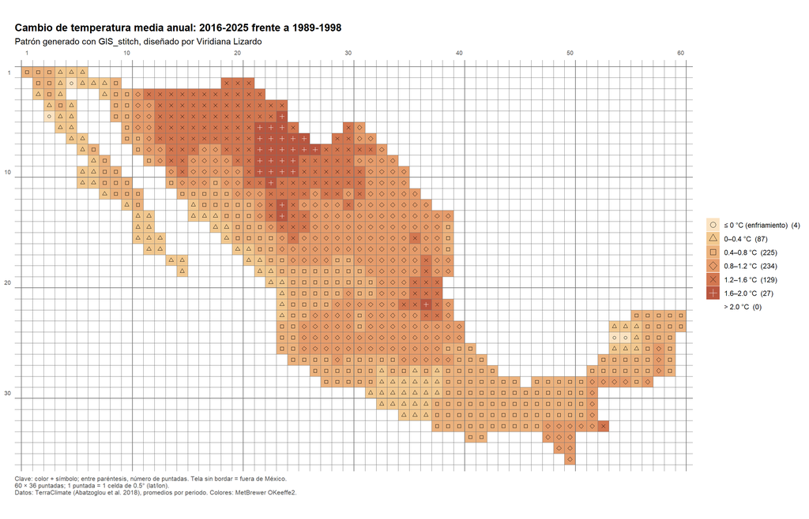

```r
pt <- patron_bordado(v$datos, "temperatura", periodo = v$inicial, ref = v$final, guardar = FALSE)
pt$grafica
```

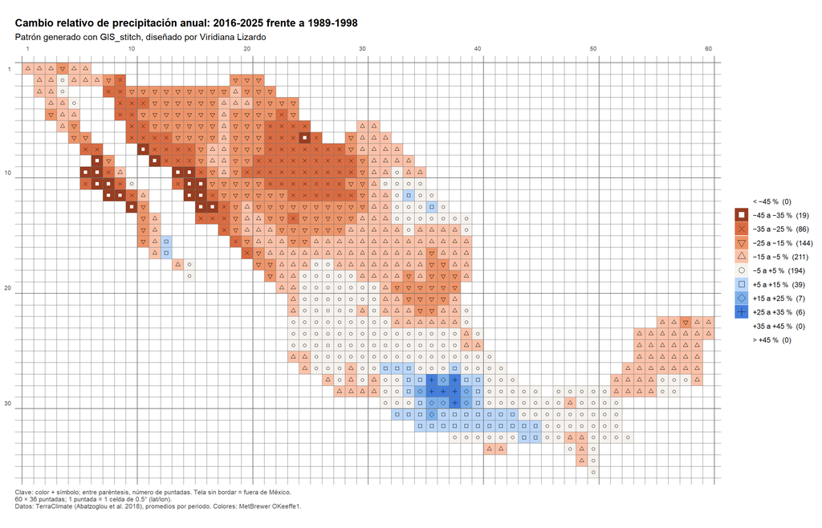

```r
pp <- patron_bordado(v$datos, "precipitacion", periodo = v$inicial, ref = v$final, guardar = FALSE)
pp$grafica
```

La lista de hilos de la temperatura:

```r
pt$clave[pt$clave$puntadas > 0, c("clase", "desde", "hasta", "color_hex", "simbolo", "puntadas")]
```

| clase | desde | hasta | color_hex | simbolo | puntadas |
| --- | --- | --- | --- | --- | --- |
| 1 | -Inf | 0.0 | #fbe3c2 | circulo | 4 |
| 2 | 0.0 | 0.4 | #f2c88f | triangulo | 87 |
| 3 | 0.4 | 0.8 | #ecb27d | cuadro | 225 |
| 4 | 0.8 | 1.2 | #e69c6b | rombo | 234 |
| 5 | 1.2 | 1.6 | #d37750 | equis | 129 |
| 6 | 1.6 | 2.0 | #b9563f | cruz | 27 |

## Lo que decide el código

En esta pieza, se puede personalizar lo siguiente

- **La resolución.** Una puntada promedia unos 3,000 km².
- **Las ventanas de 10 años.** Otra regla, otro mapa.
- **Los cortes de color.** Un corte en 1.2 °C o en 1.0 °C cambia cuántas puntadas son oscuras.

## Para reproducirlo

1. `analysis/03_series_anuales.R`: descarga TerraClimate y genera la serie anual.
2. Este documento: lee la serie, calcula los cambios y dibuja los patrones.
3. La página interactiva (`docs/index.html`) usa los mismos datos y las mismas clases para que cualquiera genere el patrón de su propio año.

**Referencia.** Abatzoglou, J. T., Dobrowski, S. Z., Parks, S. A. y Hegewisch, K. C. (2018). TerraClimate, a high-resolution global dataset of monthly climate and climatic water balance from 1958–2015. *Scientific Data*, 5, 170191.

```
## [1] "R version 4.4.1 (2024-06-14 ucrt)"
```